# Week Six: Ethics and Modeling

## From the homework…

## Excel

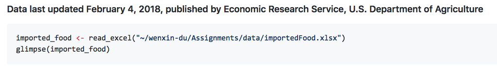

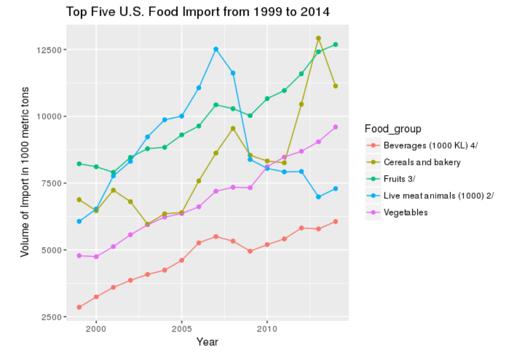

## And again

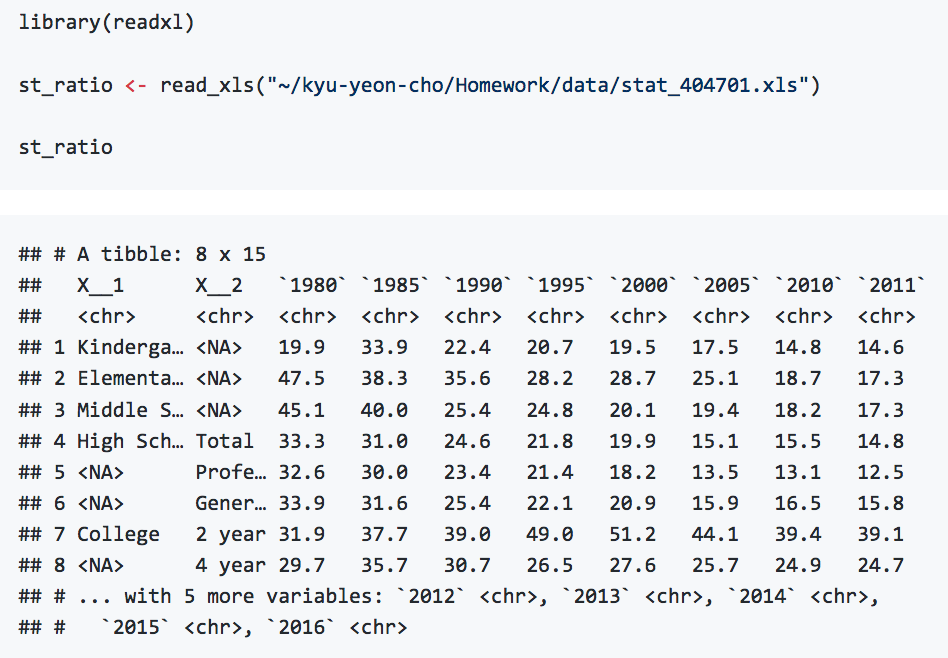

## And again

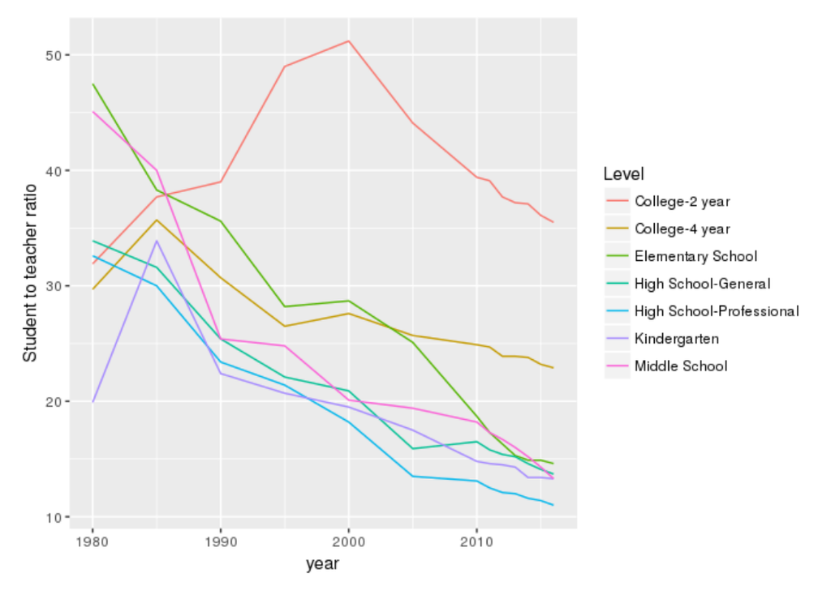

## Matlab

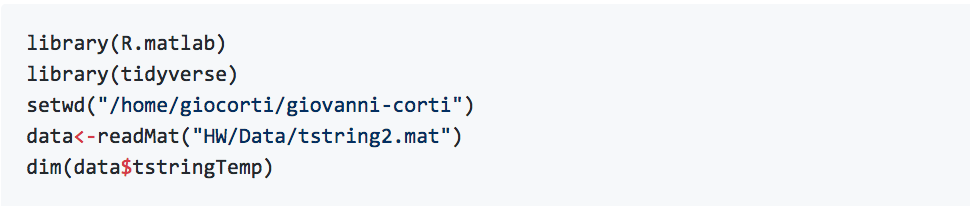

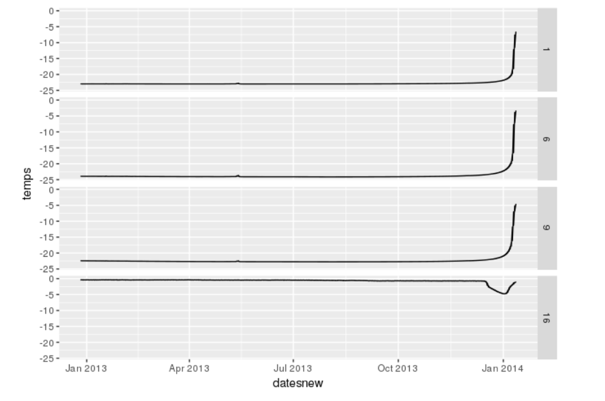

## Stata

```r
religion_survey <- read_dta("03255-0001-Data.dta")
```

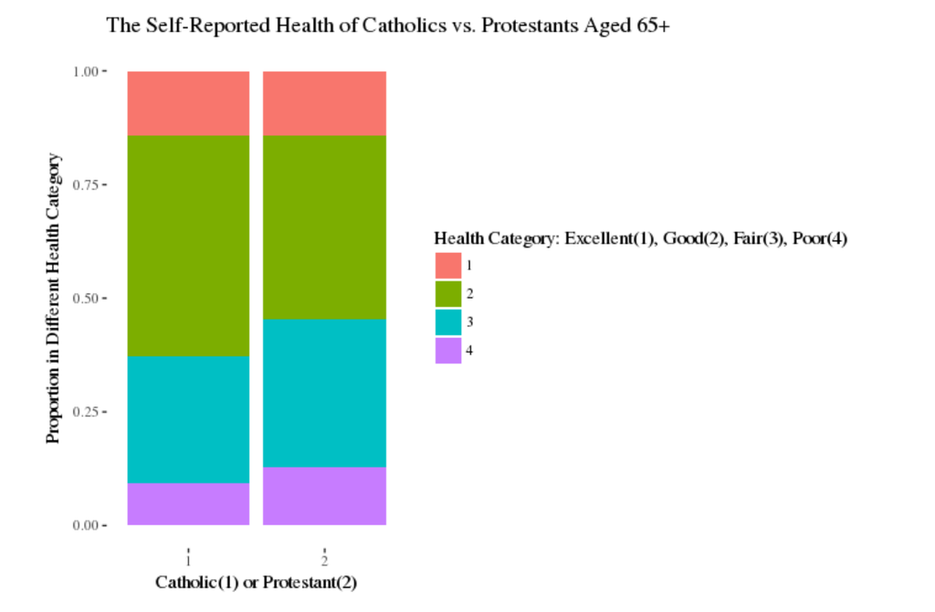

## SPSS

```r
library(foreign)
Womens_Marches<- read.spss("31102944.por", to.data.frame = TRUE)
```

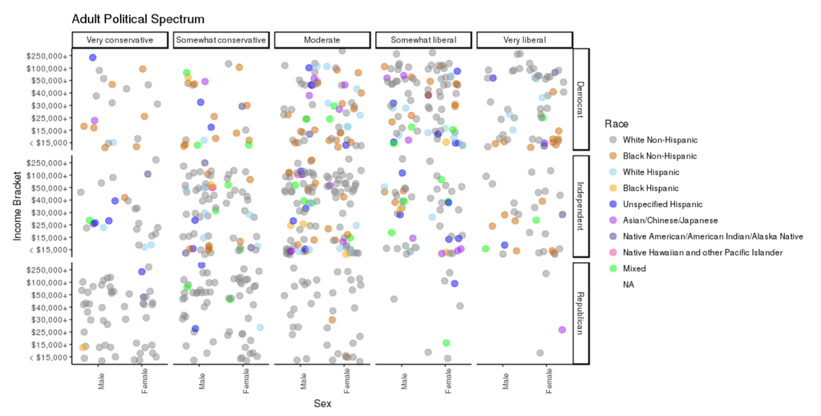

## XML

```r
library(rvest)
url <- "http://www.reed.edu/ir/averageclssz.html"
url %>% read_html()
```

```
## {xml_document}
## <html xmlns="http://www.w3.org/1999/xhtml" lang="en-us">
## [1] <head>\n<meta http-equiv="Content-Type" content="text/html; charset= ...
## [2] <body>\n<div id="accessLinks">\n<a href="#siteNav">Skip to site navi ...
```

## XML

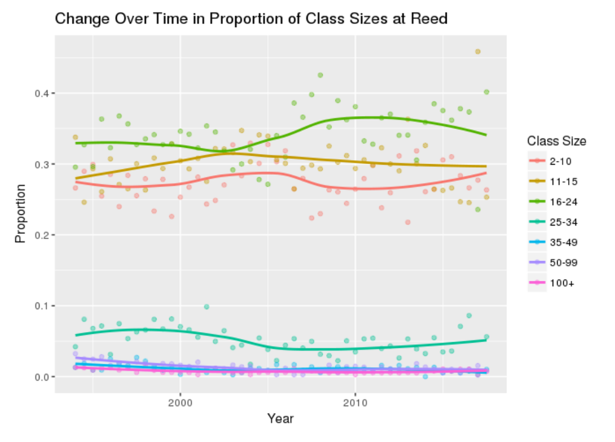

## API

[figure not shown]

```r
library(genius)
MFDOOM <- get_artist_songs(70)
MADVIL <- get_artist_songs(150)
KINGG <- get_artist_songs(708)
VIKTORV <- get_artist_songs(712)
# various alternate names
# this section uses the genius API to get lyrics and songs
```

## API

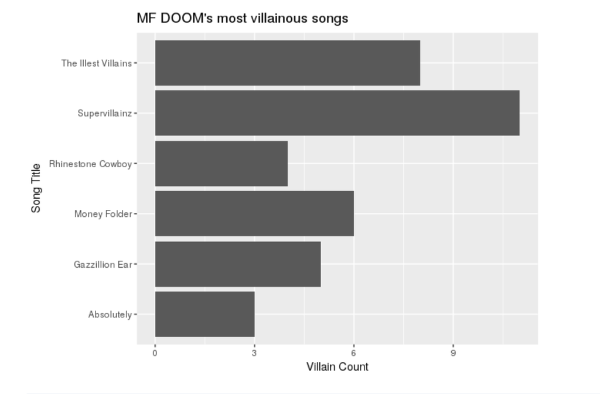

## Ethics

## Groups

Wenxin Canyon Giovanni

Frankie Clark Frank

Miranda Zeki Ryan

Henry Katie Richard

Simon Josephine Kaelyn

Ilana Lirui Kyu

Emerson Mitzi Lucas

Aaron Till

## Modeling

## Modeling diamonds

What is the relationship between `log(price)` and `carat`?

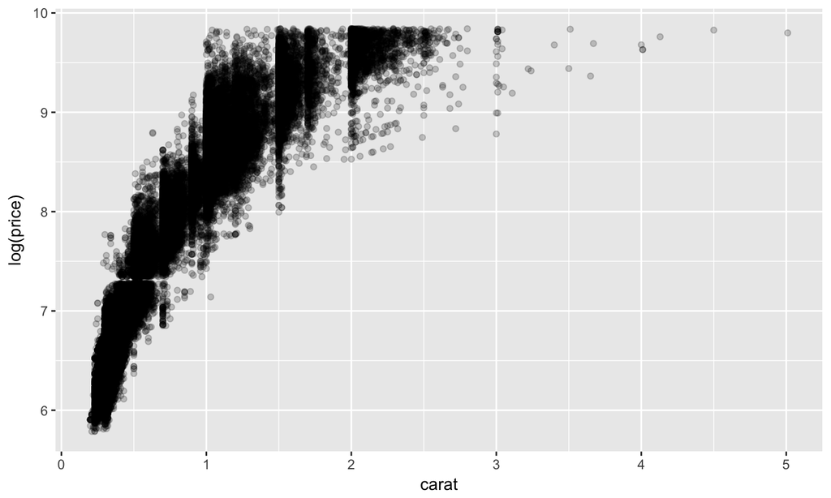

```r
ggplot(diamonds, aes(x = carat, y = log(price))) +
  geom_point(alpha = .2)
```

```r
mA <- lm(log(price) ~ carat, data = diamonds)
summary(mA)
```

```
##
## Call:
## lm(formula = log(price) ~ carat, data = diamonds)
##
## Residuals:
##     Min      1Q  Median      3Q     Max
## -6.2844 -0.2449  0.0335  0.2578  1.5642
##
## Coefficients:
##             Estimate Std. Error t value Pr(>|t|)
## (Intercept) 6.215021   0.003348    1856   <2e-16 ***
## carat       1.969757   0.003608     546   <2e-16 ***
## ---
## Signif. codes:  0 '***' 0.001 '**' 0.01 '*' 0.05 '.' 0.1 ' ' 1
##
## Residual standard error: 0.3972 on 53938 degrees of freedom
## Multiple R-squared:  0.8468, Adjusted R-squared:  0.8468
## F-statistic: 2.981e+05 on 1 and 53938 DF,  p-value: < 2.2e-16
```

Please interpret this model in a *single sentence*.

## Components of `lm()`

- Coefficient estimates: intercept, slope
- SE's on coefficients
- p-values
- Goodness of fit (\(R^2\))

For *inference*, it is essentially that our model is *valid*.

## Extracting from `lm()`

```r
str(mA)
```

[output not shown]

## Extracting from `lm()`

```r
coef(mA)
```

```
## (Intercept)       carat
##    6.215021    1.969757
```

```r
mA$coefficients
```

```
## (Intercept)       carat
##    6.215021    1.969757
```

```r
length(mA)
```

```
## [1] 12
```

```r
names(mA)
```

```
##  [1] "coefficients"  "residuals"     "effects"       "rank"
##  [5] "fitted.values" "assign"        "qr"            "df.residual"
##  [9] "xlevels"       "call"          "terms"         "model"
```

## Extracting from `lm()`

```r
head(mA$fitted.values)
```

```
##        1        2        3        4        5        6
## 6.668065 6.628670 6.668065 6.786251 6.825646 6.687763
```

```r
head(mA$residuals)
```

```
##          1          2          3          4          5          6
## -0.8811677 -0.8417726 -0.8781050 -0.9751096 -1.0115152 -0.8706515
```

## Extracting from `summary()`

```r
summ_mA <- summary(mA)
str(summ_mA)
```

```
## List of 11
##  $ call         : language lm(formula = log(price) ~ carat, data = diamonds)
##  $ terms        :Classes 'terms', 'formula'  language log(price) ~ carat
##   .. ..- attr(*, "variables")= language list(log(price), carat)
##   .. ..- attr(*, "factors")= int [1:2, 1] 0 1
##   .. .. ..- attr(*, "dimnames")=List of 2
##   .. .. .. ..$ : chr [1:2] "log(price)" "carat"
##   .. .. .. ..$ : chr "carat"
##   .. ..- attr(*, "term.labels")= chr "carat"
##   .. ..- attr(*, "order")= int 1
##   .. ..- attr(*, "intercept")= int 1
##   .. ..- attr(*, "response")= int 1
##   .. ..- attr(*, ".Environment")=<environment: R_GlobalEnv>
##   .. ..- attr(*, "predvars")= language list(log(price), carat)
##   .. ..- attr(*, "dataClasses")= Named chr [1:2] "numeric" "numeric"
##   .. .. ..- attr(*, "names")= chr [1:2] "log(price)" "carat"
##  $ residuals    : Named num [1:53940] -0.881 -0.842 -0.878 -0.975 -1.012 ...
##   ..- attr(*, "names")= chr [1:53940] "1" "2" "3" "4" ...
##  $ coefficients : num [1:2, 1:4] 6.22 1.97 3.35e-03 3.61e-03 1.86e+03 ...
##   ..- attr(*, "dimnames")=List of 2
##   .. ..$ : chr [1:2] "(Intercept)" "carat"
##   .. ..$ : chr [1:4] "Estimate" "Std. Error" "t value" "Pr(>|t|)"
##  $ aliased      : Named logi [1:2] FALSE FALSE
##   ..- attr(*, "names")= chr [1:2] "(Intercept)" "carat"
##  $ sigma        : num 0.397
##  $ df           : int [1:3] 2 53938 2
##  $ r.squared    : num 0.847
##  $ adj.r.squared: num 0.847
##  $ fstatistic   : Named num [1:3] 298092 1 53938
##   ..- attr(*, "names")= chr [1:3] "value" "numdf" "dendf"
##  $ cov.unscaled : num [1:2, 1:2] 7.11e-05 -6.58e-05 -6.58e-05 8.25e-05
##   ..- attr(*, "dimnames")=List of 2
##   .. ..$ : chr [1:2] "(Intercept)" "carat"
##   .. ..$ : chr [1:2] "(Intercept)" "carat"
##  - attr(*, "class")= chr "summary.lm"
```

## Extracting from `summary()`

```r
summ_mA <- summary(mA)
str(summ_mA)
```

[output not shown]

## Extracting from `summary()`

```r
coef(summ_mA)
```

```
##             Estimate  Std. Error   t value Pr(>|t|)
## (Intercept) 6.215021 0.003348400 1856.1164        0
## carat       1.969757 0.003607758  545.9782        0
```

```r
class(coef(summ_mA))
```

```
## [1] "matrix"
```

```r
coef(summ_mA)[1, 3]
```

```
## [1] 1856.116
```

## A note about methods

There are some functions in R that behave differently depending on what types of argument you feed them. In fact that function checked the object type then calls the appropriate method.

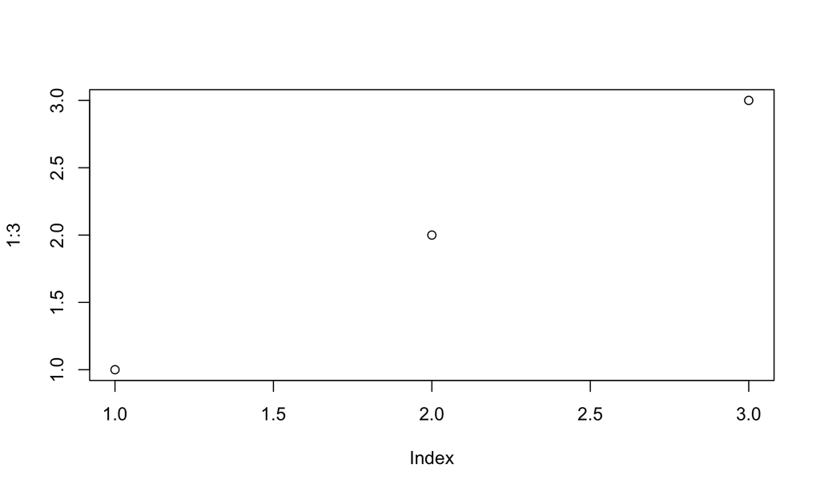

```r
plot(1:3)
```

## A note about methods

There are some functions in R that behave differently depending on what types of arguments you feed them. In fact that function checks the object type then calls the appropriate method.

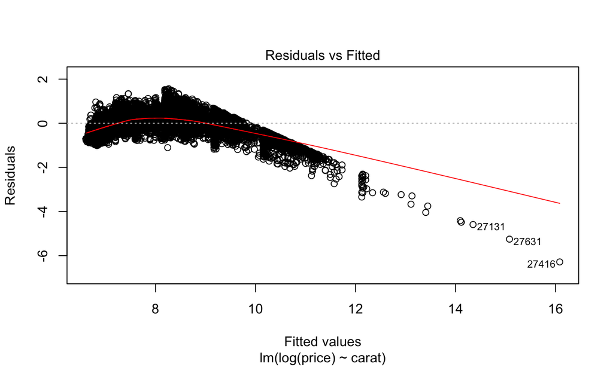

```r
plot(mA, 1)
```

## A better model?

```r
mB <- lm(log(price) ~ carat + I(carat^2), data = diamonds)
summary(mB)
```

```
##
## Call:
## lm(formula = log(price) ~ carat + I(carat^2), data = diamonds)
##
## Residuals:
##     Min      1Q  Median      3Q     Max
## -1.3724 -0.1724 -0.0023  0.1785  7.7200
##
## Coefficients:
##              Estimate Std. Error t value Pr(>|t|)
## (Intercept)  5.450685   0.003794  1436.5   <2e-16 ***
## carat        3.916561   0.008119   482.4   <2e-16 ***
## I(carat^2)  -0.916073   0.003643  -251.5   <2e-16 ***
## ---
## Signif. codes:  0 '***' 0.001 '**' 0.01 '*' 0.05 '.' 0.1 ' ' 1
##
## Residual standard error: 0.2695 on 53937 degrees of freedom
## Multiple R-squared:  0.9295, Adjusted R-squared:  0.9295
## F-statistic: 3.554e+05 on 2 and 53937 DF,  p-value: < 2.2e-16
```

## A better model?

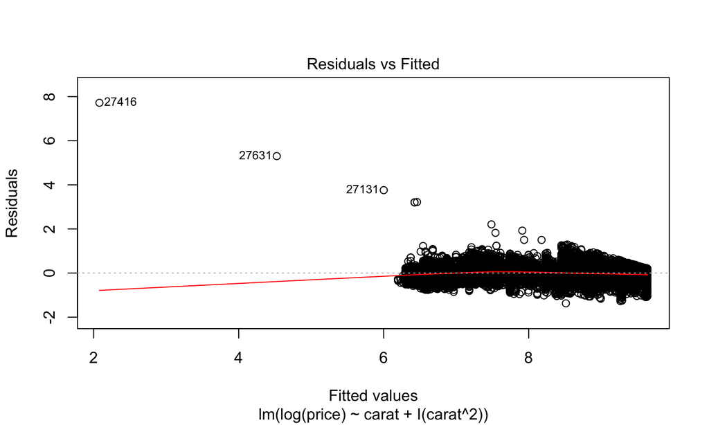

```r
plot(mB, 1)
```

## A third model

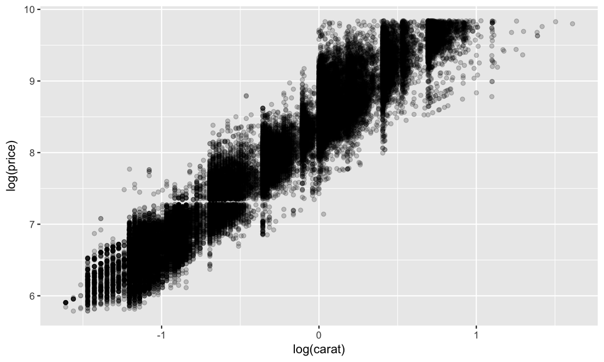

```r
ggplot(diamonds, aes(x = log(carat), y = log(price))) +
  geom_point(alpha = .2)
```

## A third model

```r
mC <- lm(log(price) ~ log(carat), data = diamonds)
summary(mC)
```

```
##
## Call:
## lm(formula = log(price) ~ log(carat), data = diamonds)
##
## Residuals:
##      Min       1Q   Median       3Q      Max
## -1.50833 -0.16951 -0.00591  0.16637  1.33793
##
## Coefficients:
##             Estimate Std. Error t value Pr(>|t|)
## (Intercept) 8.448661   0.001365  6190.9   <2e-16 ***
## log(carat)  1.675817   0.001934   866.6   <2e-16 ***
## ---
## Signif. codes:  0 '***' 0.001 '**' 0.01 '*' 0.05 '.' 0.1 ' ' 1
##
## Residual standard error: 0.2627 on 53938 degrees of freedom
## Multiple R-squared:  0.933,  Adjusted R-squared:  0.933
## F-statistic: 7.51e+05 on 1 and 53938 DF,  p-value: < 2.2e-16
```

## A third model

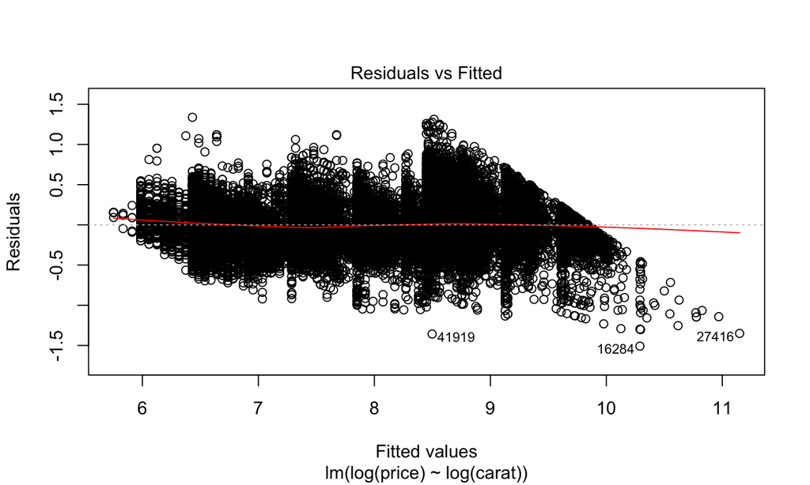

```r
plot(mC, 1)
```

## Comparing models

The choice of criterion depends on the modeling goal.

1. Predictive accuracy (\(R^2_{adj}\), test-train MSE)
2. Model validity

## A different question

What is the relationship between `log(price)` and `cut`?

```r
mD <- lm(log(price) ~ cut, data = diamonds)
summary(mD)
```

```
##
## Call:
## lm(formula = log(price) ~ cut, data = diamonds)
##
## Residuals:
##      Min       1Q   Median       3Q      Max
## -2.27336 -0.89757 -0.00737  0.77876  2.20246
##
## Coefficients:
##              Estimate Std. Error  t value Pr(>|t|)
## (Intercept)  7.865035   0.006443 1220.692  < 2e-16 ***
## cut.L       -0.252970   0.017259  -14.658  < 2e-16 ***
## cut.Q        0.020014   0.015384    1.301    0.193
## cut.C       -0.211855   0.013387  -15.825  < 2e-16 ***
## cut^4       -0.077633   0.010795   -7.192 6.48e-13 ***
## ---
## Signif. codes:  0 '***' 0.001 '**' 0.01 '*' 0.05 '.' 0.1 ' ' 1
##
## Residual standard error: 1.005 on 53935 degrees of freedom
## Multiple R-squared:  0.01814,    Adjusted R-squared:  0.01806
## F-statistic: 249.1 on 4 and 53935 DF,  p-value: < 2.2e-16
```

## A different question

What is the relationship between `log(price)` and `cut` when controlling for `log(carat)`?

```r
mE <- lm(log(price) ~ log(carat) + cut, data = diamonds)
summary(mE)
```

```
##
## Call:
## lm(formula = log(price) ~ log(carat) + cut, data = diamonds)
##
## Residuals:
##      Min       1Q   Median       3Q      Max
## -1.52247 -0.16484 -0.00587  0.16087  1.38115
##
## Coefficients:
##              Estimate Std. Error  t value Pr(>|t|)
## (Intercept)  8.392010   0.001735 4835.551  < 2e-16 ***
## log(carat)   1.695771   0.001910  887.679  < 2e-16 ***
## cut.L        0.224330   0.004401   50.970  < 2e-16 ***
## cut.Q       -0.066427   0.003895  -17.054  < 2e-16 ***
## cut.C        0.052895   0.003402   15.550  < 2e-16 ***
## cut^4        0.018632   0.002734    6.814  9.6e-12 ***
## ---
## Signif. codes:  0 '***' 0.001 '**' 0.01 '*' 0.05 '.' 0.1 ' ' 1
##
## Residual standard error: 0.2545 on 53934 degrees of freedom
## Multiple R-squared:  0.9371, Adjusted R-squared:  0.9371
## F-statistic: 1.607e+05 on 5 and 53934 DF,  p-value: < 2.2e-16
```

## A different question

What is the relationship between `log(price)` and `cut` when controlling for `log(carat)`?

```r
d2 <- diamonds %>%
  mutate(cut = factor(cut, ordered = FALSE))
mF <- lm(log(price) ~ log(carat) + cut, data = d2)
summary(mF)
```

```
##
## Call:
## lm(formula = log(price) ~ log(carat) + cut, data = d2)
##
## Residuals:
##      Min       1Q   Median       3Q      Max
## -1.52247 -0.16484 -0.00587  0.16087  1.38115
##
## Coefficients:
##              Estimate Std. Error t value Pr(>|t|)
## (Intercept)  8.200125   0.006343 1292.69   <2e-16 ***
## log(carat)   1.695771   0.001910  887.68   <2e-16 ***
## cutGood      0.163245   0.007324   22.29   <2e-16 ***
## cutVery Good 0.240753   0.006779   35.52   <2e-16 ***
## cutPremium   0.238217   0.006716   35.47   <2e-16 ***
## cutIdeal     0.317212   0.006632   47.83   <2e-16 ***
## ---
## Signif. codes:  0 '***' 0.001 '**' 0.01 '*' 0.05 '.' 0.1 ' ' 1
##
## Residual standard error: 0.2545 on 53934 degrees of freedom
## Multiple R-squared:  0.9371, Adjusted R-squared:  0.9371
## F-statistic: 1.607e+05 on 5 and 53934 DF,  p-value: < 2.2e-16
```

## Summary

- Models are more extensible and formal way to describe relationships in data
- The quality of your prediction and/or inference is dependent on a wise choice of model
- Think about models as a *specific answer* to a *specific question*.
- Coefficient estimates will change based on which variables you add to the model.
- Be sure to distinguish between *statistical significance* and *practical significance*.

## Activity (in pairs)

The `SatatogaHouses` data set in the `mosaicData` package provides information on 1728 houses that sold in Saratoga County, NY in 2006.

1. Formulate a question that can be answered with this data set.
2. Create a visualization of the data relevant to that question (using 3 - 5 variables).
3. Fit a formal linear model relevant to that question.